# EDA & Data Manipulation – More Covariates

2023-01-27

# Exploratory Data Analysis and More Data Manipulation

```r
library(dplyr)
library(tidyverse)
library(readstata13)
library(ggplot2)
w1_netm <- read.dta13("Data-Stata/our_data/w1_netm.dta", convert.factors = F)
w1_ym <- read.dta13("Data-Stata/our_data/w1_ym.dta", convert.factors = F)
```

```r
covars <- c("youthidCUF","classidCUF","schoolidCUF","schtype_geRV","y1_sex","y1_doby","y1_nationRV","y1_lpsc1","y1_lpsc2","y1_lpsc3","y1_lpsc4","y1_fact","y1_sat2","y1_pbsch1","y1_pbsch2","y1_pbsch3","y1_pbsch4","y1_del1","y1_del2","y1_del3","y1_del4","y1_vict1","y1_vict2","y1_vict3","y1_pdisc1","y1_pdisc2","y1_pdisc3","y1_pdisc4","y1_date","y1_contm","y1_gawm","y1_contf","y1_gawf","y1_penc1","y1_penc2","y1_penc3","y1_fcoh1","y1_fcoh2","y1_fcoh3","y1_fcoh4","y1_fcoh5","y1_pdem1","y1_pdem2","y1_pdem3","y1_pdem4","y1_pdem5","y1_pdem6","y1_pdem7","y1_pinv1","y1_pinv2","y1_pinv3")

# deviance and delinquency in school -- y1_pbsch1 : y1_del4
# perceived victim / discrimination in school -- y1_vict1 : y1_pdisc4
# romantic relationship -- y1_date (currently dating?)
# family relations -- y1_contm : y1_contf
# parental encouragement -- y1_penc1 : y1_penc3
# family cohesion -- y1_fcoh1 : y1_fcoh5
# parenting style -- demandingness -- y1_pdem1:y1_pdem7
# parenting style -- involvement -- y1_pinv1:y1_pinv3

# well-being
# self esteem -- y1_sest1:y1_sest4

# attitudes toward school
# teachers encouragement y1_tenc1 : y1_tenc3

main1 <- w1_ym[covars]
main1 <- w1_ym %>%
  select(youthidCUF, classidCUF, schoolidCUF, schtype_geRV,
         y1_sex, y1_doby, y1_nationRV, y1_lpsc1:y1_lpsc4,
         y1_fact, y1_sat2, y1_sat1, y1_pbsch1:y1_pbsch4,
         y1_del1:y1_del4, y1_vict1:y1_vict3,y1_pdisc1:y1_pdisc4,
         y1_date, y1_contm,y1_gawm, y1_contf, y1_gawf,
         y1_penc1:y1_penc3, y1_fcoh1:y1_fcoh5, y1_pdem1:y1_pdem7,
         y1_pinv1:y1_pinv3, y1_sest1:y1_sest4,
         y1_tenc1:y1_tenc3
         )

main1[main1 < 0] <- NA
main1$age <- 2010 - main1$y1_doby
main1 <- merge(main1, w1_netm, by = c("youthidCUF","classidCUF"))

write_csv(main1,"Data-Stata/our_data/all_data.csv")
```

#### School Type (Germany) — `schtype_geRV`

- 1 = Lower secondary school
- 2 = School combining several tracks
- 3 = Intermediate secondary school
- 4 = Comprehensive school / Rudolf-Steiner School
- 5 = Upper secondary school
- 6 = School for special needs

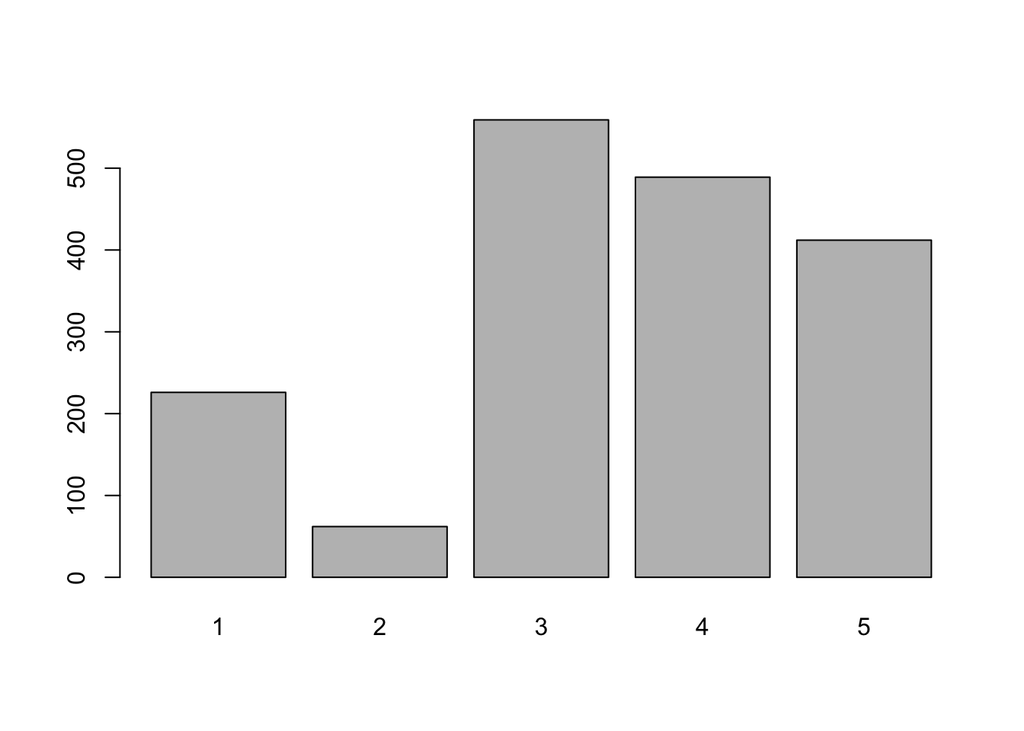

```
## main1$schtype_geRV
##       Frequency Percent
## 1           226  12.929
## 2            62   3.547
## 3           559  31.979
## 4           489  27.975
## 5           412  23.570
## Total      1748 100.000
```

```r
# univariate analysis of school type
descr::freq(main1$schtype_geRV)
```

## Cultural Integration

### Language measures – proficiency in survey country language (German)

- 5-point Likert type (1 = Not at all, 2 = Not well … 5 = Excellently)
- four sub-measures regarding speak, read, write, understand

Data manipulation –> recode them into 0 to 4 for each measure and sum them up

```r
# recode multiple variables whose levels are 1 to 5 into 0 to 4
main2 <- main1 %>%
  mutate_at(vars(y1_lpsc1:y1_lpsc4), funs(.-1))

# check summary stats
print("Before recoding")
```

```
## [1] "Before recoding"
```

```r
summary((main1 %>% select(y1_lpsc1:y1_lpsc4)))
```

```
##     y1_lpsc1        y1_lpsc2        y1_lpsc3        y1_lpsc4
##  Min.   :2.000   Min.   :2.000   Min.   :1.000   Min.   :1.000
##  1st Qu.:4.000   1st Qu.:4.000   1st Qu.:4.000   1st Qu.:3.000
##  Median :4.000   Median :5.000   Median :4.000   Median :4.000
##  Mean   :4.261   Mean   :4.457   Mean   :4.208   Mean   :3.874
##  3rd Qu.:5.000   3rd Qu.:5.000   3rd Qu.:5.000   3rd Qu.:4.000
##  Max.   :5.000   Max.   :5.000   Max.   :5.000   Max.   :5.000
##  NA's   :2       NA's   :5       NA's   :5       NA's   :6
```

```r
print("After recoding")
```

```
## [1] "After recoding"
```

```r
summary((main2 %>% select(y1_lpsc1:y1_lpsc4)))
```

```
##     y1_lpsc1        y1_lpsc2        y1_lpsc3        y1_lpsc4
##  Min.   :1.000   Min.   :1.000   Min.   :0.000   Min.   :0.000
##  1st Qu.:3.000   1st Qu.:3.000   1st Qu.:3.000   1st Qu.:2.000
##  Median :3.000   Median :4.000   Median :3.000   Median :3.000
##  Mean   :3.261   Mean   :3.457   Mean   :3.208   Mean   :2.874
##  3rd Qu.:4.000   3rd Qu.:4.000   3rd Qu.:4.000   3rd Qu.:3.000
##  Max.   :4.000   Max.   :4.000   Max.   :4.000   Max.   :4.000
##  NA's   :2       NA's   :5       NA's   :5       NA's   :6
```

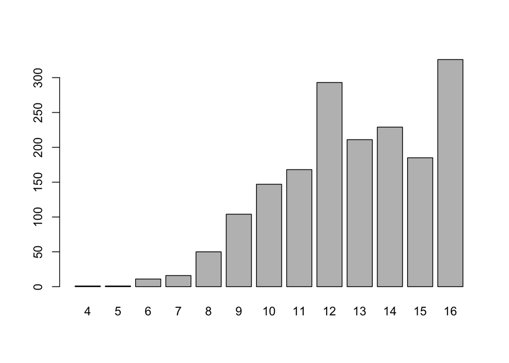

```
## main2$language
##       Frequency   Percent Valid Percent
## 4             1   0.05721       0.05741
## 5             1   0.05721       0.05741
## 6            11   0.62929       0.63146
## 7            16   0.91533       0.91848
## 8            50   2.86041       2.87026
## 9           104   5.94966       5.97015
## 10          147   8.40961       8.43858
## 11          168   9.61098       9.64409
## 12          293  16.76201      16.81975
## 13          211  12.07094      12.11251
## 14          229  13.10069      13.14581
## 15          185  10.58352      10.61998
## 16          326  18.64989      18.71412
## NA's          6   0.34325
## Total      1748 100.00000     100.00000
```

```r
main2 <- main2 %>%
  mutate(language = y1_lpsc1 + y1_lpsc2 + y1_lpsc3 + y1_lpsc4)
descr::freq(main2$language)
```

## Socio-Demography and Migration

### Gender — `y1_sex`

- 1 = Boy
- 2 = Girl

```r
# add factor variable of gender
main2$gender = ifelse(main2$y1_sex == 1, "Boy", "Girl")
descr::freq(main2$gender, plot = FALSE)
```

```
## main2$gender
##       Frequency Percent
## Boy         804      46
## Girl        944      54
## Total      1748     100
```

### Age — `y1_doby` (when were you born? Year)

```r
descr::freq(main2$age, plot = FALSE)
```

```
## main2$age
##       Frequency   Percent Valid Percent
## 13           12   0.68650        0.6869
## 14          716  40.96110       40.9845
## 15          824  47.13959       47.1666
## 16          179  10.24027       10.2461
## 17           16   0.91533        0.9159
## NA's          1   0.05721
## Total      1748 100.00000      100.0000
```

### Nationality — `y1_nationRV`

- 1 = Only survey country nationality
- 2 = Survey country and other nationality
- 3 = Only other nationality

```r
main2 <- main2 %>%
  mutate(nationality = case_when(
    y1_nationRV == 1 ~ "German only",
    y1_nationRV == 2 ~ "German and other nationality",
    y1_nationRV == 3 ~ "Only other nationality",),
    nationality = factor(nationality,
                            levels=c("German only",
                                     "German and other nationality",
                                     "Only other nationality")))

# check for recoding
print("Before recoding")
```

```
## [1] "Before recoding"
```

```r
descr::freq(main1$y1_nationRV,plot = FALSE)
```

```
## main1$y1_nationRV
##       Frequency Percent Valid Percent
## 1          1328  75.973        76.763
## 2           159   9.096         9.191
## 3           243  13.902        14.046
## NA's         18   1.030
## Total      1748 100.000       100.000
```

```r
print("After recoding")
```

```
## [1] "After recoding"
```

```r
descr::freq(main2$nationality,plot = FALSE)
```

```
## main2$nationality
##                              Frequency Percent Valid Percent
## German only                       1328  75.973        76.763
## German and other nationality       159   9.096         9.191
## Only other nationality             243  13.902        14.046
## NA's                                18   1.030
## Total                             1748 100.000       100.000
```

##### Correlation Matrix

```r
library(corrplot)
library(Hmisc)

mydata.cor = cor(na.omit(main1[,-c(1:3,6)]), method = c("spearman"))
mydata.cor
corrplot(mydata.cor, method = "color")
```

[output not shown]

##### Summary Statistics

```r
# change gender/ nationality / school type as factor
summary(main1 %>%
  mutate(classidCUF = as.factor(classidCUF),
         schoolidCUF = as.factor(schoolidCUF),
         y1_sex = as.factor(y1_sex),
         schtype_geRV = as.factor(schtype_geRV),
         y1_nationRV = as.factor(y1_nationRV),
         y1_fact = as.factor(y1_fact)) %>%
  select(-youthidCUF))
```

[output not shown]

## Economic situation

### `y1_fact` — can’t afford friends’ activities

- 1 = Always
- 2 = Often
- 3 = Sometimes
- 4 = Never

```r
descr::freq(main1$y1_fact, plot = FALSE)
```

```
## main1$y1_fact
##       Frequency Percent Valid Percent
## 1            39   2.231         2.359
## 2            65   3.719         3.932
## 3           423  24.199        25.590
## 4          1126  64.416        68.119
## NA's         95   5.435
## Total      1748 100.000       100.000
```

## Structual Integration

### Deviance & Delinquency at school

#### `y1_pbsch1` How often do exihibit following problem behaviors in school?

argue with teacher | get a punishment in school (e.g. being kept in detention, sent out of class, writing lines) | skip a lesson without permission? | come late to school?

Response: - 1 = every day

- 2 = once or several times a week
- 3 = once or several times a month
- 4 = less often
- 5 = never

```r
# recoding problem behavioral measures
main2 <- main2 %>%
  mutate_at(vars(y1_pbsch1:y1_pbsch4), ~ 5-.) %>%
  mutate(problem_behaviors = y1_pbsch1 + y1_pbsch2 + y1_pbsch3 + y1_pbsch4)
# check before recoding
print("Before recoding")
```

```
## [1] "Before recoding"
```

```r
descr::freq(main1$y1_pbsch1, plot = FALSE)
```

```
## main1$y1_pbsch1
##       Frequency  Percent Valid Percent
## 1            15   0.8581        0.8621
## 2            89   5.0915        5.1149
## 3           157   8.9817        9.0230
## 4           665  38.0435       38.2184
## 5           814  46.5675       46.7816
## NA's          8   0.4577
## Total      1748 100.0000      100.0000
```

```r
print("After recoding")
```

```
## [1] "After recoding"
```

```r
descr::freq(main2$y1_pbsch1, plot = FALSE)
```

```
## main2$y1_pbsch1
##       Frequency  Percent Valid Percent
## 0           814  46.5675       46.7816
## 1           665  38.0435       38.2184
## 2           157   8.9817        9.0230
## 3            89   5.0915        5.1149
## 4            15   0.8581        0.8621
## NA's          8   0.4577
## Total      1748 100.0000      100.0000
```

```r
print("Frequency of problem behaviors")
```

```
## [1] "Frequency of problem behaviors"
```

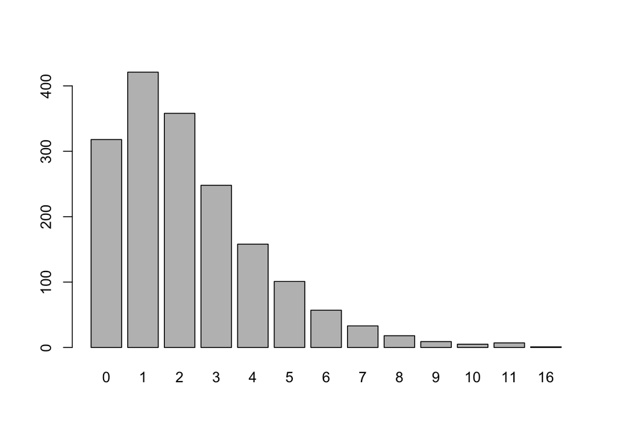

```
## main2$problem_behaviors
##       Frequency   Percent Valid Percent
## 0           318  18.19222      18.33910
## 1           421  24.08467      24.27912
## 2           358  20.48055      20.64591
## 3           248  14.18764      14.30219
## 4           158   9.03890       9.11188
## 5           101   5.77803       5.82468
## 6            57   3.26087       3.28720
## 7            33   1.88787       1.90311
## 8            18   1.02975       1.03806
## 9             9   0.51487       0.51903
## 10            5   0.28604       0.28835
## 11            7   0.40046       0.40369
## 16            1   0.05721       0.05767
## NA's         14   0.80092
## Total      1748 100.00000     100.00000
```

```r
descr::freq(main2$problem_behaviors)
```

#### `y1_del1` — Delinquent behavior: Deliberately damaged things that were not yours

```r
main2 <- main2 %>%
  mutate_at(vars(y1_del1:y1_del4),
            funs(replace(., . == 2,0)))

print("Before recoding")
```

```
## [1] "Before recoding"
```

```r
summary(main1 %>% mutate_at(vars(y1_del1:y1_del4), as.factor) %>% select(y1_del1 : y1_del4))
```

```
##  y1_del1     y1_del2     y1_del3     y1_del4
##  1   : 121   1   :  60   1   : 137   1   : 250
##  2   :1335   2   :1397   2   :1320   2   :1207
##  NA's: 292   NA's: 291   NA's: 291   NA's: 291
```

```r
print("After recoding")
```

```
## [1] "After recoding"
```

```r
summary(main2 %>% mutate_at(vars(y1_del1:y1_del4), as.factor) %>% select(y1_del1 : y1_del4))
```

```
##  y1_del1     y1_del2     y1_del3     y1_del4
##  0   :1335   0   :1397   0   :1320   0   :1207
##  1   : 121   1   :  60   1   : 137   1   : 250
##  NA's: 292   NA's: 291   NA's: 291   NA's: 291
```

```r
# if or not they have delinquency behavior
main2 <- main2 %>%
  mutate(delinquency_history = ifelse(rowSums(
    select(.,y1_del1:y1_del4) == 1) > 0,
    'yes','no'),
    delinquency_count = y1_del1 + y1_del2 + y1_del3 + y1_del4)

print("Delinquency history frequency")
```

```
## [1] "Delinquency history frequency"
```

```r
descr::freq(main2$delinquency_history,plot = FALSE)
```

```
## main2$delinquency_history
##       Frequency Percent Valid Percent
## no         1038   59.38         71.39
## yes         416   23.80         28.61
## NA's        294   16.82
## Total      1748  100.00        100.00
```

```r
print("Delinquency count frequency")
```

```
## [1] "Delinquency count frequency"
```

```r
descr::freq(main2$delinquency_count,plot = FALSE)
```

```
## main2$delinquency_count
##       Frequency  Percent Valid Percent
## 0          1038  59.3822       71.3893
## 1           301  17.2197       20.7015
## 2            86   4.9199        5.9147
## 3            23   1.3158        1.5818
## 4             6   0.3432        0.4127
## NA's        294  16.8192
## Total      1748 100.0000      100.0000
```

### Discrimination at school

Note that we donnot use perceived discrimination measures as they occur outside school setting! #### `y1_vict1:y1_vict3` – Victim at school following types: scared of other students | teased by other students | bullied by other students

Responses: - 1 = every day - 2 = once or several times a week - 3 = less often - 4 = never

```r
main2 <- main2 %>%
  mutate_at(vars(y1_vict1:y1_vict3),  ~4-.)

print("Before recoding")
```

```
## [1] "Before recoding"
```

```r
summary(main1 %>% mutate_at(vars(y1_vict1:y1_vict3), as.factor) %>% select(y1_vict1:y1_vict3))
```

```
##  y1_vict1    y1_vict2    y1_vict3
##  1   :   4   1   :  25   1   :  14
##  2   :  40   2   : 111   2   :  64
##  3   : 288   3   : 484   3   : 169
##  4   :1407   4   :1119   4   :1491
##  NA's:   9   NA's:   9   NA's:  10
```

```r
print("After recoding")
```

```
## [1] "After recoding"
```

```r
summary(main2 %>% mutate_at(vars(y1_vict1:y1_vict3), as.factor) %>% select(y1_vict1:y1_vict3))
```

```
##  y1_vict1    y1_vict2    y1_vict3
##  0   :1407   0   :1119   0   :1491
##  1   : 288   1   : 484   1   : 169
##  2   :  40   2   : 111   2   :  64
##  3   :   4   3   :  25   3   :  14
##  NA's:   9   NA's:   9   NA's:  10
```

```r
main2 <- main2 %>%
  mutate(victim_history = ifelse(rowSums(
    select(.,y1_vict1:y1_vict3) == 1) > 0,
    1,0)) %>%
  mutate_at(vars(y1_vict1:y1_vict3),
         funs(ifelse(. == 3, 5, # every day
                     ifelse(. == 2, 4, # once or several times a week
                            ifelse(. == 1, 2, .) # less often
                            )
                     )
              )
         ) # never
main2 <- main2 %>%
  mutate(victim_history_score = y1_vict1 + y1_vict2 + y1_vict3)
descr::freq(main2$victim_history,plot = FALSE)
```

```
## main2$victim_history
##       Frequency  Percent Valid Percent
## 0          1084  62.0137         62.44
## 1           652  37.2998         37.56
## NA's         12   0.6865
## Total      1748 100.0000        100.00
```

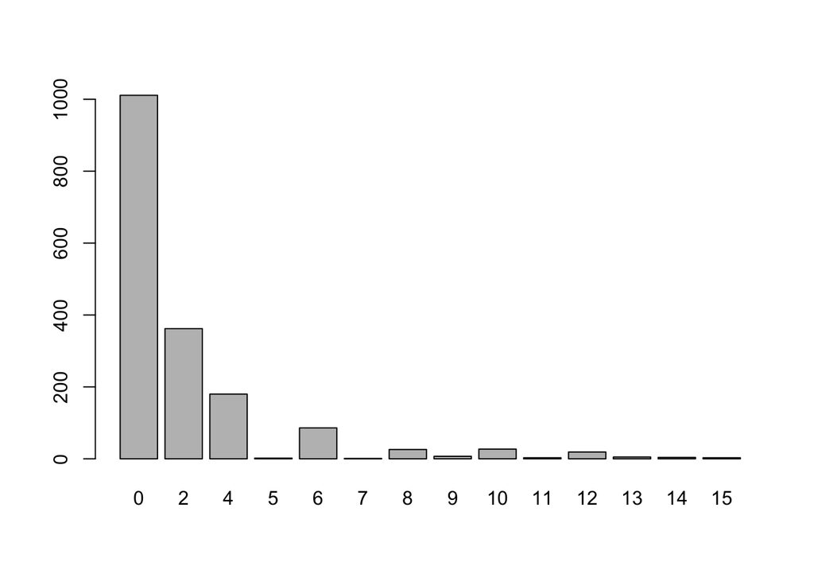

```
## main2$victim_history_score
##       Frequency   Percent Valid Percent
## 0          1011  57.83753       58.2373
## 2           362  20.70938       20.8525
## 4           180  10.29748       10.3687
## 5             2   0.11442        0.1152
## 6            86   4.91991        4.9539
## 7             1   0.05721        0.0576
## 8            26   1.48741        1.4977
## 9             7   0.40046        0.4032
## 10           27   1.54462        1.5553
## 11            3   0.17162        0.1728
## 12           19   1.08696        1.0945
## 13            5   0.28604        0.2880
## 14            4   0.22883        0.2304
## 15            3   0.17162        0.1728
## NA's         12   0.68650
## Total      1748 100.00000      100.0000
```

```r
descr::freq(main2$victim_history_score)
```

```r
print("After recoding stage two")
```

```
## [1] "After recoding stage two"
```

```r
summary(main2 %>% mutate_at(vars(y1_vict1:y1_vict3), as.factor) %>% select(y1_vict1:y1_vict3))
```

```
##  y1_vict1    y1_vict2    y1_vict3
##  0   :1407   0   :1119   0   :1491
##  2   : 288   2   : 484   2   : 169
##  4   :  40   4   : 111   4   :  64
##  5   :   4   5   :  25   5   :  14
##  NA's:   9   NA's:   9   NA's:  10
```

### Family

#### Family Relation

##### `y1_gawm | y1_gawf` — how well do you get along with your mother/father?

- 1 = every very well
- 2 = well
- 3 = not so well
- 4 = not well at all

```r
# if or not they have delinquency behavior
main2 <- main2 %>%
  mutate_at(vars(y1_gawm,y1_gawf), ~4-.) %>%
  mutate(parent_relation = round((y1_gawf + y1_gawm)/2)) # average score of how well they get along with parents

print("Before recoding")
```

```
## [1] "Before recoding"
```

```r
summary(main1 %>% mutate_at(vars(y1_gawm,y1_gawf), as.factor) %>% select(y1_gawm,y1_gawf))
```

```
##  y1_gawm    y1_gawf
##  1   :985   1   :882
##  2   :613   2   :595
##  3   : 86   3   :101
##  4   : 16   4   : 17
##  NA's: 48   NA's:153
```

```r
print("After recoding")
```

```
## [1] "After recoding"
```

```r
summary(main2 %>% mutate_at(vars(y1_gawm,y1_gawf), as.factor) %>% select(y1_gawm,y1_gawf))
```

```
##  y1_gawm    y1_gawf
##  0   : 16   0   : 17
##  1   : 86   1   :101
##  2   :613   2   :595
##  3   :985   3   :882
##  NA's: 48   NA's:153
```

```r
print("Parental relation")
```

```
## [1] "Parental relation"
```

```r
descr::freq(main2$parent_relation,plot = FALSE)
```

```
## main2$parent_relation
##       Frequency Percent Valid Percent
## 0             5   0.286        0.3203
## 1            26   1.487        1.6656
## 2           900  51.487       57.6553
## 3           630  36.041       40.3587
## NA's        187  10.698
## Total      1748 100.000      100.0000
```

## School satisfication

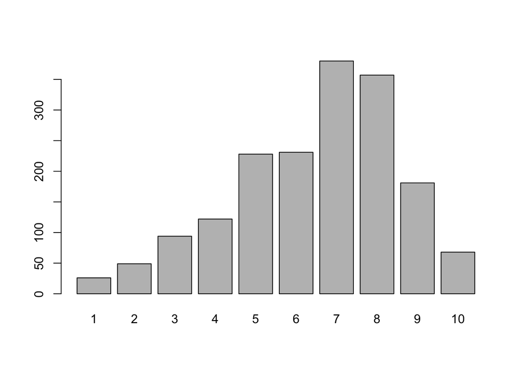

```
## main2$y1_sat2
##       Frequency  Percent Valid Percent
## 1            26   1.4874         1.498
## 2            49   2.8032         2.823
## 3            94   5.3776         5.415
## 4           122   6.9794         7.028
## 5           228  13.0435        13.134
## 6           231  13.2151        13.306
## 7           380  21.7391        21.889
## 8           357  20.4233        20.565
## 9           181  10.3547        10.426
## 10           68   3.8902         3.917
## NA's         12   0.6865
## Total      1748 100.0000       100.000
```

```r
descr::freq(main2$y1_sat2)
```

### Self-esteem

#### `y1_sest1:y1_sest4` following measures:

I have a lot of good qualities | have a lot to be proud of | like myself just the way I am | think things will go well for me in the future

Response: - 1 = strongly agree - 2 = agree - 3 = neither agree nor disagree - 4 = disagree - 5 = strongly disagree

```r
jsonlite::write_json(main2, "Data-Stata/our_data/CILS4EU.json")
write_csv(main2, "Data-Stata/our_data/all_main.csv")
```